# HEADS 22-26

LEARN - Assignment 1

Vera Pinheiro

2023/02/27

```r
knitr::opts_chunk$set(echo = TRUE)
```

## Package Import

My aim was to study the associations between several recorded risk factors and the risk of developing cervical cancer, using the patient pool in the risk_factors_cervical_cancer.csv dataset, which was built in order to predict risk factors for cervical cancer. This dataset was collected at “Hospital Universitario de Caracas” in Caracas, Venezuela, and comprises demographic information, habits, and historic medical records of 858 patients.

```r
# Importing the necessary packages

library(rio)          # Import function for multiple file formats
library(tidyverse)    # Data wrangling and visualization
library(janitor)      # Data examining and cleaning functions
library(summarytools) # Descriptive statistics
library(skimr)        # EDA
library(kableExtra)   # Display and format html tables
library(broom)        # Functions to tidy outputs
library(tidymodels)   # Modeling and statistical analysis that share the underlying philosophy of the tidyverse.
library(caret)        # For Classification and Regression Training
library(rpart)        # To build Decision Trees
library(pROC)         # To create ROC curves
library(naivebayes)   # To create Naive Bayes models
library(tinytex)      # To create PDF report
```

## Data Import

```r
# Immporting the dataset directly from the website
dataset_og <- rio::import(file = "https://archive.ics.uci.edu/ml/machine-learning-databases/00383/risk_factors_cervical_cancer.csv",
                  setclass = "tibble") %>%
  janitor::clean_names()

# Pre-process the dataset
dataset <- dataset_og %>%
  mutate(across(everything(), as.numeric)) %>% #forces "?" to NA
  mutate(across(c(10, 12, 14:25, 29:36), ~ factor(., levels = c(0,1), labels = c("No","Yes")))) %>% #Convert the appropriate columns to factor
  mutate(across(c(1:5, 8, 13, 26:28), as.integer)) %>% #Convert the appropriate columns to integer
  rename_all(.funs = ~ str_replace_all(names(dataset_og),"st_ds","stds")) %>%
  mutate(across(where(is.factor), ~ factor(.x, levels=rev(levels(.x)))))  %>% # so that Yes is considered the positive value in caret
  select(-c(dx:biopsy)) # remove other target variables and highly correlated variables (dx_hpv)

# Display the structure
str(dataset)
```

```
## tibble [858 × 31] (S3: tbl_df/tbl/data.frame)
##  $ age                               : int [1:858] 18 15 34 52 46 42 51 26 45 44 ...
##  $ number_of_sexual_partners         : int [1:858] 4 1 1 5 3 3 3 1 1 3 ...
##  $ first_sexual_intercourse          : int [1:858] 15 14 NA 16 21 23 17 26 20 15 ...
##  $ num_of_pregnancies                : int [1:858] 1 1 1 4 4 2 6 3 5 NA ...
##  $ smokes                            : int [1:858] 0 0 0 1 0 0 1 0 0 1 ...
##  $ smokes_years                      : num [1:858] 0 0 0 37 0 ...
##  $ smokes_packs_year                 : num [1:858] 0 0 0 37 0 0 3.4 0 0 2.8 ...
##  $ hormonal_contraceptives           : int [1:858] 0 0 0 1 1 0 0 1 0 0 ...
##  $ hormonal_contraceptives_years     : num [1:858] 0 0 0 3 15 0 0 2 0 0 ...
##  $ iud                               : Factor w/ 2 levels "Yes","No": 2 2 2 2 2 2 1 1 2 NA ...
##  $ iud_years                         : num [1:858] 0 0 0 0 0 0 7 7 0 NA ...
##  $ stds                              : Factor w/ 2 levels "Yes","No": 2 2 2 2 2 2 2 2 2 2 ...
##  $ stds_number                       : int [1:858] 0 0 0 0 0 0 0 0 0 0 ...
##  $ stds_condylomatosis               : Factor w/ 2 levels "Yes","No": 2 2 2 2 2 2 2 2 2 2 ...
```

[output cut: 17 more lines]

## Descriptive statistics

The `skim` function (from the package `skimr`) is great for an extensive and yet understandable descriptive statistic summary. It also allows for data quality checks, and we can see clearly that some variables have a lot of missings, and will be problematic when running the models.

```r
skim(dataset)
```

Data summary

| Name | dataset |
| --- | --- |
| Number of rows | 858 |
| Number of columns | 31 |
| _______________________ |  |
| Column type frequency: |  |
| factor | 17 |
| numeric | 14 |
| ________________________ |  |
| Group variables | None |

**Variable type: factor**

| skim_variable | n_missing | complete_rate | ordered | n_unique | top_counts |
| --- | --- | --- | --- | --- | --- |
| iud | 117 | 0.86 | FALSE | 2 | No: 658, Yes: 83 |
| stds | 105 | 0.88 | FALSE | 2 | No: 674, Yes: 79 |
| stds_condylomatosis | 105 | 0.88 | FALSE | 2 | No: 709, Yes: 44 |
| stds_cervical_condylomatosis | 105 | 0.88 | FALSE | 1 | No: 753, Yes: 0 |
| stds_vaginal_condylomatosis | 105 | 0.88 | FALSE | 2 | No: 749, Yes: 4 |
| stds_vulvo_perineal_condylomatosis | 105 | 0.88 | FALSE | 2 | No: 710, Yes: 43 |
| stds_syphilis | 105 | 0.88 | FALSE | 2 | No: 735, Yes: 18 |
| stds_pelvic_inflammatory_disease | 105 | 0.88 | FALSE | 2 | No: 752, Yes: 1 |
| stds_genital_herpes | 105 | 0.88 | FALSE | 2 | No: 752, Yes: 1 |
| stds_molluscum_contagiosum | 105 | 0.88 | FALSE | 2 | No: 752, Yes: 1 |
| stds_aids | 105 | 0.88 | FALSE | 1 | No: 753, Yes: 0 |
| stds_hiv | 105 | 0.88 | FALSE | 2 | No: 735, Yes: 18 |
| stds_hepatitis_b | 105 | 0.88 | FALSE | 2 | No: 752, Yes: 1 |
| stds_hpv | 105 | 0.88 | FALSE | 2 | No: 751, Yes: 2 |
| dx_cancer | 0 | 1.00 | FALSE | 2 | No: 840, Yes: 18 |
| dx_cin | 0 | 1.00 | FALSE | 2 | No: 849, Yes: 9 |
| dx_hpv | 0 | 1.00 | FALSE | 2 | No: 840, Yes: 18 |

**Variable type: numeric**

| skim_variable | n_missing | complete_rate | mean | sd | p0 | p25 | p50 | p75 | p100 | hist |
| --- | --- | --- | --- | --- | --- | --- | --- | --- | --- | --- |
| age | 0 | 1.00 | 26.82 | 8.50 | 13 | 20 | 25.0 | 32.0 | 84 | ▇▅▁▁▁ |
| number_of_sexual_partners | 26 | 0.97 | 2.53 | 1.67 | 1 | 2 | 2.0 | 3.0 | 28 | ▇▁▁▁▁ |
| first_sexual_intercourse | 7 | 0.99 | 17.00 | 2.80 | 10 | 15 | 17.0 | 18.0 | 32 | ▂▇▂▁▁ |
| num_of_pregnancies | 56 | 0.93 | 2.28 | 1.45 | 0 | 1 | 2.0 | 3.0 | 11 | ▇▃▁▁▁ |
| smokes | 13 | 0.98 | 0.15 | 0.35 | 0 | 0 | 0.0 | 0.0 | 1 | ▇▁▁▁▂ |
| smokes_years | 13 | 0.98 | 1.22 | 4.09 | 0 | 0 | 0.0 | 0.0 | 37 | ▇▁▁▁▁ |
| smokes_packs_year | 13 | 0.98 | 0.45 | 2.23 | 0 | 0 | 0.0 | 0.0 | 37 | ▇▁▁▁▁ |
| hormonal_contraceptives | 108 | 0.87 | 0.64 | 0.48 | 0 | 0 | 1.0 | 1.0 | 1 | ▅▁▁▁▇ |
| hormonal_contraceptives_years | 108 | 0.87 | 2.26 | 3.76 | 0 | 0 | 0.5 | 3.0 | 30 | ▇▁▁▁▁ |
| iud_years | 117 | 0.86 | 0.51 | 1.94 | 0 | 0 | 0.0 | 0.0 | 19 | ▇▁▁▁▁ |
| stds_number | 105 | 0.88 | 0.18 | 0.56 | 0 | 0 | 0.0 | 0.0 | 4 | ▇▁▁▁▁ |
| stds_number_of_diagnosis | 0 | 1.00 | 0.09 | 0.30 | 0 | 0 | 0.0 | 0.0 | 3 | ▇▁▁▁▁ |
| stds_time_since_first_diagnosis | 787 | 0.08 | 6.14 | 5.90 | 1 | 2 | 4.0 | 8.0 | 22 | ▇▂▁▁▁ |
| stds_time_since_last_diagnosis | 787 | 0.08 | 5.82 | 5.76 | 1 | 2 | 3.0 | 7.5 | 22 | ▇▂▁▁▁ |

## Model development

As requested, decision trees were built initially (`tree.gini` and `tree.information`).

Unfortunately, the R Version of this laptop (`R version 3.6.3 (2020-02-29)`), meant that package RandomForest was impossible to install.

```r
# Warning in install.packages :
#  package ‘RandomForest’ is not available (for R version 3.6.3)
```

```r
#Set seed for reproducibility
set.seed(523)

#Prepare dataset for model evaluation
prep_dataset <- dataset %>%
  dplyr::select(-c(10, 15, 22, 27, 28)) %>% # variables with only 1 level + high % of missings
  drop_na()

summary(prep_dataset)
```

```
##       age        number_of_sexual_partners first_sexual_intercourse
##  Min.   :13.00   Min.   : 1.000            Min.   :10.00
##  1st Qu.:21.00   1st Qu.: 2.000            1st Qu.:15.00
##  Median :26.00   Median : 2.000            Median :17.00
##  Mean   :27.26   Mean   : 2.524            Mean   :17.14
##  3rd Qu.:33.00   3rd Qu.: 3.000            3rd Qu.:18.00
##  Max.   :84.00   Max.   :28.000            Max.   :32.00
##  num_of_pregnancies     smokes        smokes_years    smokes_packs_year
##  Min.   : 0.000     Min.   :0.0000   Min.   : 0.000   Min.   : 0.000
##  1st Qu.: 1.000     1st Qu.:0.0000   1st Qu.: 0.000   1st Qu.: 0.000
##  Median : 2.000     Median :0.0000   Median : 0.000   Median : 0.000
##  Mean   : 2.323     Mean   :0.1437   Mean   : 1.236   Mean   : 0.459
##  3rd Qu.: 3.000     3rd Qu.:0.0000   3rd Qu.: 0.000   3rd Qu.: 0.000
##  Max.   :11.000     Max.   :1.0000   Max.   :37.000   Max.   :37.000
##  hormonal_contraceptives hormonal_contraceptives_years   iud_years
##  Min.   :0.0000          Min.   : 0.00                 Min.   : 0.00
##  1st Qu.:0.0000          1st Qu.: 0.00                 1st Qu.: 0.00
##  Median :1.0000          Median : 0.50                 Median : 0.00
##  Mean   :0.6437          Mean   : 2.29                 Mean   : 0.53
##  3rd Qu.:1.0000          3rd Qu.: 3.00                 3rd Qu.: 0.00
##  Max.   :1.0000          Max.   :22.00                 Max.   :19.00
##   stds      stds_number     stds_condylomatosis stds_vaginal_condylomatosis
##  Yes: 65   Min.   :0.0000   Yes: 37             Yes:  4
##  No :603   1st Qu.:0.0000   No :631             No :664
##            Median :0.0000
##            Mean   :0.1662
##            3rd Qu.:0.0000
##            Max.   :4.0000
##  stds_vulvo_perineal_condylomatosis stds_syphilis
##  Yes: 36                            Yes: 15
##  No :632                            No :653
##
##
##
##
##  stds_pelvic_inflammatory_disease stds_genital_herpes
##  Yes:  1                          Yes:  1
##  No :667                          No :667
##
##
##
##
##  stds_molluscum_contagiosum stds_hiv  stds_hepatitis_b stds_hpv
##  Yes:  1                    Yes: 13   Yes:  1          Yes:  2
##  No :667                    No :655   No :667          No :666
##
##
##
##
##  stds_number_of_diagnosis dx_cancer dx_cin    dx_hpv
##  Min.   :0.00000          Yes: 17   Yes:  3   Yes: 16
##  1st Qu.:0.00000          No :651   No :665   No :652
##  Median :0.00000
##  Mean   :0.09281
##  3rd Qu.:0.00000
##  Max.   :3.00000
```

```r
# Holdout a validation set, by defining the indices of the training set
training.index <- createDataPartition(prep_dataset$dx_cancer, p=0.8, list=FALSE)
validation <- prep_dataset[-training.index,]
dataset <- prep_dataset[training.index,]


# Levels of the class
levels(prep_dataset$dx_cancer)
```

```
## [1] "Yes" "No"
```

```r
# Class distribution
proportions <- prop.table(table(prep_dataset$dx_cancer))
cbind(Frequency=table(prep_dataset$dx_cancer), Proportion=round(proportions*100,2))
```

```
##     Frequency Proportion
## Yes        17       2.54
## No        651      97.46
```

```r
# Learn tree with Gini impurity
tree.gini <- rpart(dx_cancer ~ ., data=prep_dataset)
# Learn tree with information gain
tree.information <- rpart(dx_cancer ~ ., data=prep_dataset,
                          parms = list(split = "information"))

# Summary
summary(tree.information)
```

```
## Call:
## rpart(formula = dx_cancer ~ ., data = prep_dataset, parms = list(split = "information"))
##   n= 668
##
##          CP nsplit rel error    xerror      xstd
## 1 0.8235294      0 1.0000000 1.0000000 0.2394296
## 2 0.0100000      1 0.1764706 0.1764706 0.1016563
##
## Variable importance
##   dx_hpv stds_hpv
##       89       11
##
## Node number 1: 668 observations,    complexity param=0.8235294
##   predicted class=No   expected loss=0.0254491  P(node) =1
##     class counts:    17   651
##    probabilities: 0.025 0.975
##   left son=2 (16 obs) right son=3 (652 obs)
##   Primary splits:
##       dx_hpv                        splits as  LR,       improve=61.878710, (0 missing)
##       age                           < 26.5 to the right, improve= 6.415703, (0 missing)
##       first_sexual_intercourse      < 17.5 to the right, improve= 5.478249, (0 missing)
##       iud_years                     < 2.5  to the right, improve= 3.841127, (0 missing)
##       hormonal_contraceptives_years < 14.5 to the right, improve= 1.755743, (0 missing)
##   Surrogate splits:
##       stds_hpv splits as  LR, agree=0.979, adj=0.125, (0 split)
##
## Node number 2: 16 observations
##   predicted class=Yes  expected loss=0.0625  P(node) =0.0239521
##     class counts:    15     1
##    probabilities: 0.937 0.063
##
## Node number 3: 652 observations
##   predicted class=No   expected loss=0.003067485  P(node) =0.9760479
##     class counts:     2   650
##    probabilities: 0.003 0.997
```

```r
summary(tree.gini)
```

```
## Call:
## rpart(formula = dx_cancer ~ ., data = prep_dataset)
##   n= 668
##
##          CP nsplit rel error    xerror      xstd
## 1 0.8235294      0 1.0000000 1.0000000 0.2394296
## 2 0.0100000      1 0.1764706 0.1764706 0.1016563
##
## Variable importance
##   dx_hpv stds_hpv
##       89       11
##
## Node number 1: 668 observations,    complexity param=0.8235294
##   predicted class=No   expected loss=0.0254491  P(node) =1
##     class counts:    17   651
##    probabilities: 0.025 0.975
##   left son=2 (16 obs) right son=3 (652 obs)
##   Primary splits:
##       dx_hpv                        splits as  LR,       improve=27.2720000, (0 missing)
##       iud_years                     < 2.5  to the right, improve= 0.6204053, (0 missing)
##       age                           < 26.5 to the right, improve= 0.5726820, (0 missing)
##       first_sexual_intercourse      < 17.5 to the right, improve= 0.5580827, (0 missing)
##       hormonal_contraceptives_years < 14.5 to the right, improve= 0.3249146, (0 missing)
##   Surrogate splits:
##       stds_hpv splits as  LR, agree=0.979, adj=0.125, (0 split)
##
## Node number 2: 16 observations
##   predicted class=Yes  expected loss=0.0625  P(node) =0.0239521
##     class counts:    15     1
##    probabilities: 0.937 0.063
##
## Node number 3: 652 observations
##   predicted class=No   expected loss=0.003067485  P(node) =0.9760479
##     class counts:     2   650
##    probabilities: 0.003 0.997
```

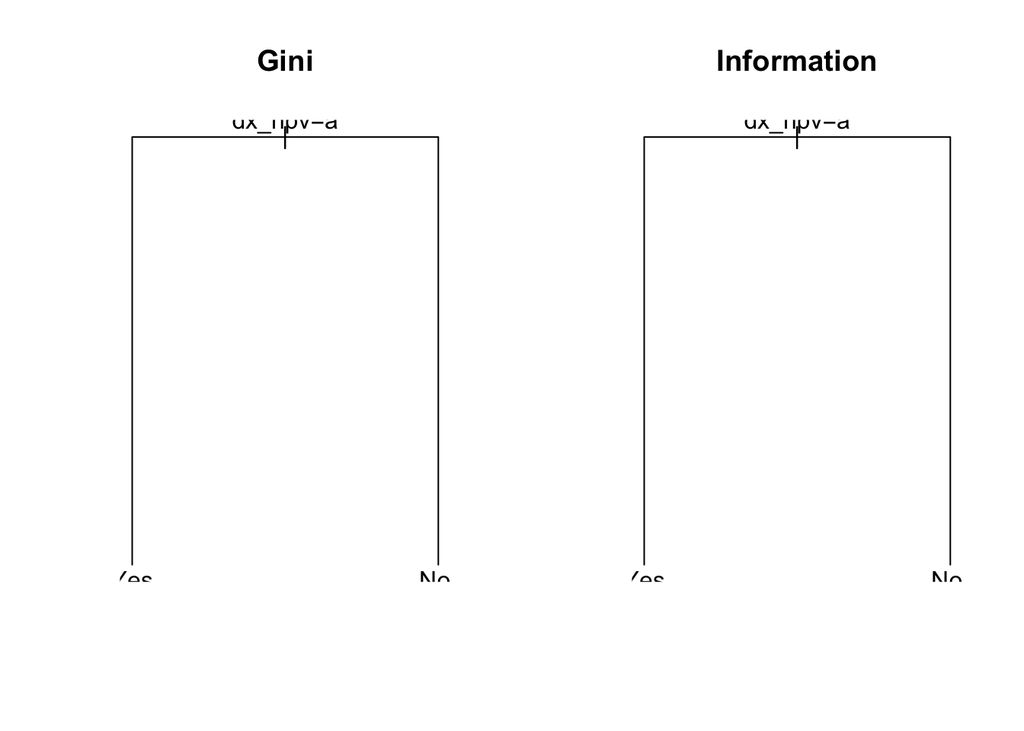

```r
# Plot
par(mfrow=c(1,2))
plot(tree.gini, main="Gini")
text(tree.gini)
plot(tree.information, main="Information")
text(tree.information)
```

Evidently, the HPV variable is the one leading this decision tree. This also happens because this dataset is highly unbalanced - most cases with HPV have cancer.

## Model evaluation through various methods

3 model algorithms were built: - Recursive Partitioning and Regression Trees (`rpart`) - K-nearest Neighbors (`knn`) - Naive Bayesian Networks (`bayes`)

In order to evaluate the models, the ROC metric was used. ROC stands for Receiver Operating Characteristics, and it is a graph of True Positive Rate (sensitivity) vs False Positive Rate (1-Specificity) of the model. It allows the analysis of the impact of these parameters on the error. AUC, which ranges between 0 and 1, is the proportion of the ROC plot that is underneath the curve, and is useful as a single number summary of classifier performance - Higher value = better classifier.

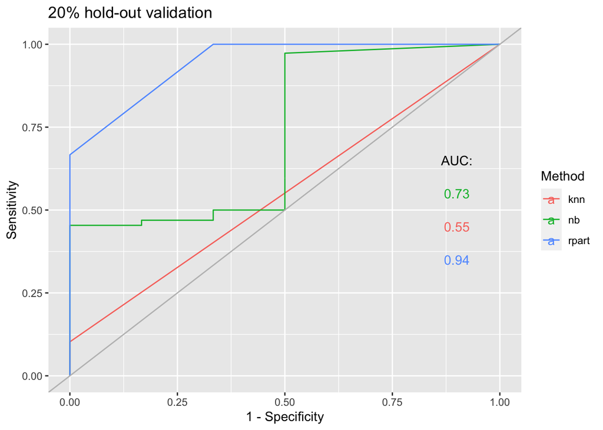

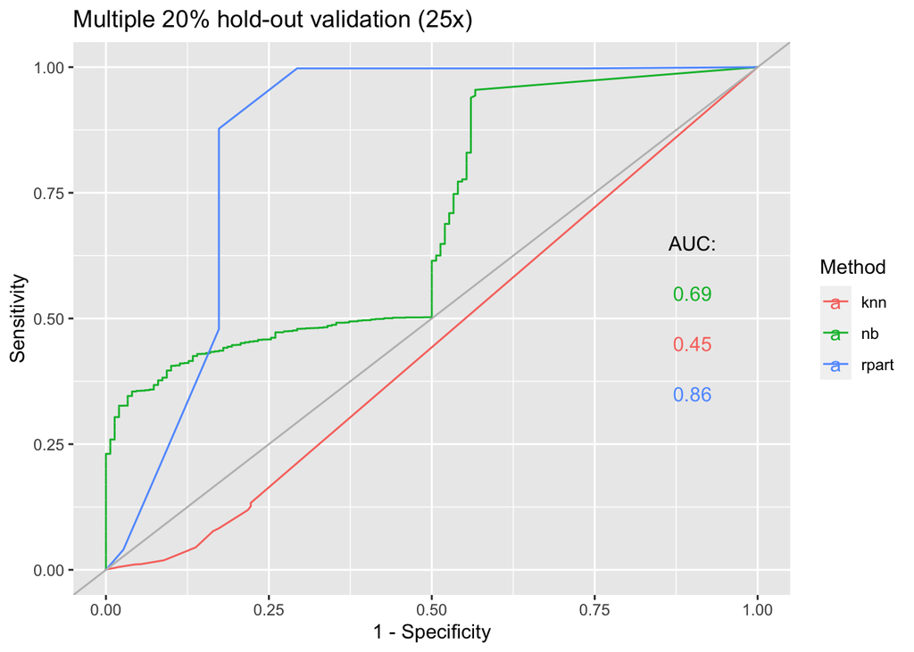

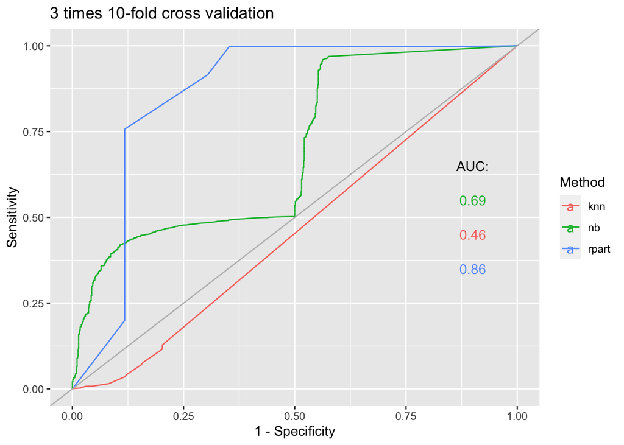

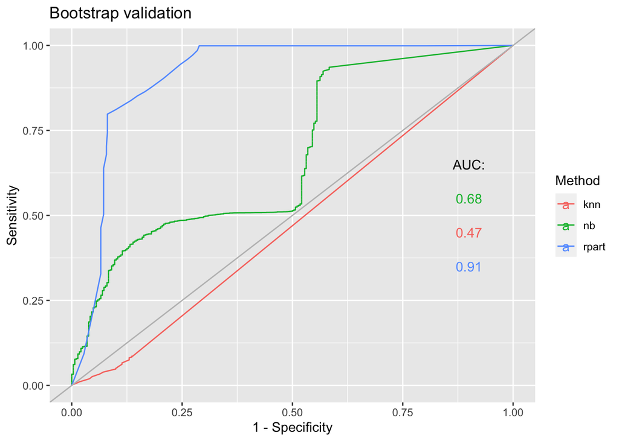

```r
# Tibble with all types of evaluation methods to explore
control_params <- tibble(method = c("LGOCV","LGOCV","repeatedcv","boot_all"),
                         p = c(0.8,0.8,NA,NA),
                         number = c(1,25,10,25),
                         repeats = c(NA,NA,25,NA),
                         desc = c("20% hold-out validation", "Multiple 20% hold-out validation (25x)","3 times 10-fold cross validation", "Bootstrap validation"))

# Iterate over control_params to create a trainControl function

train_controls <- control_params %>%
  pmap(.f = ~ trainControl(method = ..1, p = ..2, number = ..3, repeats = ..4, summaryFunction=twoClassSummary, classProbs=T, savePredictions = T))

# Recursive Partitioning and Regression Trees
set.seed(7)
rpart <- train_controls %>%
  map(.f = ~ train(dx_cancer ~ ., data=prep_dataset, method = "rpart", metric = "ROC", trControl = .x))

# Naive Bayes
set.seed(7)
naive_bayes <- train_controls %>%
  map(.f = ~ train(dx_cancer ~ ., data=prep_dataset, method = "naive_bayes", metric = "ROC", trControl = .x))

# KNN
set.seed(7)
knn <- train_controls %>%
  map(.f = ~ train(dx_cancer ~ ., data=prep_dataset, method = "knn", metric = "ROC", trControl = .x))

names(rpart) <- names(naive_bayes) <- names(knn) <- control_params$desc

# Custom function to plot ROC curves for the 3 selected methods (Decision tree, naive bayes and neural network) in the same plot, for a given validation method
custom_roc_plot <- function(validation_type) {

  #get roc data
  knn_roc <- pROC::roc(knn[[validation_type]]$pred$obs, knn[[validation_type]]$pred$Yes)
  naive_bayes_roc <- pROC::roc(naive_bayes[[validation_type]]$pred$obs, naive_bayes[[validation_type]]$pred$Yes)
  rpart_roc <- pROC::roc(rpart[[validation_type]]$pred$obs, rpart[[validation_type]]$pred$Yes)


  #sensitivities and specificities
  knn_data <- tibble(Sensitivity = knn_roc$sensitivities,
                      Specificity = knn_roc$specificities,
                      Method="knn")
  naive_bayes_data <- tibble(Sensitivity = naive_bayes_roc$sensitivities,
                             Specificity = naive_bayes_roc$specificities,
                             Method="nb")
  rpart_data <- tibble(Sensitivity = rpart_roc$sensitivities,
                       Specificity = rpart_roc$specificities,
                       Method="rpart")

  all_data <- bind_rows(knn_data, naive_bayes_data, rpart_data)

  #AUC
  all_auc <- tibble(names = c("knn","nb","rpart"),
                    values = c(knn_roc$auc,naive_bayes_roc$auc, rpart_roc$auc))

  #Return the plot
  return(
    ggplot() +
      geom_path(data = all_data, aes(y = Sensitivity, x = 1 - Specificity, group=Method, color=Method)) +
      geom_abline(intercept = 0, color="gray") +
      geom_text(aes(x=0.9, y = 0.65, label ="AUC:")) +
      geom_text(data = all_auc, aes(x=rep(0.9,3), y = c(0.45, 0.55, 0.35), color = names, label=scales::number(values))) +
      labs(title = validation_type)
  )
}

# Selected validation methods
control_params$desc %>%
  map(custom_roc_plot)
```

The Recursive Partitioning and Regression Trees had the highest AUC, making it the algorithm with the best predictive power. It was with this one that I then wanted to make predictions.

```r
#_ summarize Best Model
print(rpart)
```

```
## $`20% hold-out validation`
## CART
##
## 668 samples
##  25 predictor
##   2 classes: 'Yes', 'No'
##
## No pre-processing
## Resampling: Repeated Train/Test Splits Estimated (1 reps, 80%)
## Summary of sample sizes: 535
## Resampling results across tuning parameters:
##
##   cp         ROC  Sens  Spec
##   0.0000000  1.0  1     1
##   0.4117647  1.0  1     1
##   0.8235294  0.5  0     1
##
## ROC was used to select the optimal model using the largest value.
## The final value used for the model was cp = 0.4117647.
##
## $`Multiple 20% hold-out validation (25x)`
## CART
##
## 668 samples
##  25 predictor
##   2 classes: 'Yes', 'No'
##
## No pre-processing
## Resampling: Repeated Train/Test Splits Estimated (25 reps, 80%)
## Summary of sample sizes: 535, 535, 535, 535, 535, 535, ...
## Resampling results across tuning parameters:
##
##   cp         ROC        Sens       Spec
##   0.0000000  0.9121026  0.8266667  0.9975385
##   0.4117647  0.9121026  0.8266667  0.9975385
##   0.8235294  0.7321026  0.4666667  0.9975385
##
## ROC was used to select the optimal model using the largest value.
## The final value used for the model was cp = 0.4117647.
##
```

[output cut: 28 more lines]

```
## Resampling: Bootstrapped (25 reps)
## Summary of sample sizes: 668, 668, 668, 668, 668, 668, ...
## Resampling results across tuning parameters:
##
##   cp         ROC        Sens       Spec       ROC_632    Sens_632   Spec_632
##   0.0000000  0.9560339  0.9134762  0.9982985  0.9502856  0.9020266  0.9983594
##   0.4117647  0.9560583  0.9134762  0.9986404  0.9503010  0.9020266  0.9985755
##   0.8235294  0.6668359  0.3343492  0.9993225  0.6054604  0.2113490  0.9995718
##   ROC_OptBoot  Sens_OptBoot  Spec_OptBoot
##   0.9461669     0.8938559    0.9983995
##   0.9503155     0.9021696    0.9984615
##   0.4903408    -0.0190727    0.9997543
##
## ROC was used to select the optimal model using the largest value.
## The final value used for the model was cp = 0.4117647.
```

It must be stressed that the HPV variable must be causing high instability in this model - and that can be seen from the model statistics.

## Model Predictions

```r
#_ Make predictions ####
# Estimate skill of RPART on the validation dataset, for each validation method
predictions_rpart_1 <- predict(rpart$`20% hold-out validation`, validation)
confusionMatrix(predictions_rpart_1, validation$dx_cancer)
```

```
## Confusion Matrix and Statistics
##
##           Reference
## Prediction Yes  No
##        Yes   3   0
##        No    0 130
##
##                Accuracy : 1
##                  95% CI : (0.9726, 1)
##     No Information Rate : 0.9774
##     P-Value [Acc > NIR] : 0.04811
##
##                   Kappa : 1
##
##  Mcnemar's Test P-Value : NA
##
##             Sensitivity : 1.00000
##             Specificity : 1.00000
##          Pos Pred Value : 1.00000
##          Neg Pred Value : 1.00000
##              Prevalence : 0.02256
##          Detection Rate : 0.02256
##    Detection Prevalence : 0.02256
##       Balanced Accuracy : 1.00000
##
##        'Positive' Class : Yes
##
```

```r
predictions_rpart_2 <- predict(rpart$`Multiple 20% hold-out validation (25x)`, validation)
confusionMatrix(predictions_rpart_2, validation$dx_cancer)
```

```
## Confusion Matrix and Statistics
##
##           Reference
## Prediction Yes  No
##        Yes   3   0
##        No    0 130
##
##                Accuracy : 1
##                  95% CI : (0.9726, 1)
##     No Information Rate : 0.9774
##     P-Value [Acc > NIR] : 0.04811
##
##                   Kappa : 1
##
##  Mcnemar's Test P-Value : NA
##
##             Sensitivity : 1.00000
##             Specificity : 1.00000
##          Pos Pred Value : 1.00000
##          Neg Pred Value : 1.00000
##              Prevalence : 0.02256
##          Detection Rate : 0.02256
##    Detection Prevalence : 0.02256
##       Balanced Accuracy : 1.00000
##
##        'Positive' Class : Yes
##
```

```r
predictions_rpart_3 <- predict(rpart$`3 times 10-fold cross validation`, validation)
confusionMatrix(predictions_rpart_3, validation$dx_cancer)
```

```
## Confusion Matrix and Statistics
##
##           Reference
## Prediction Yes  No
##        Yes   3   0
##        No    0 130
##
##                Accuracy : 1
##                  95% CI : (0.9726, 1)
##     No Information Rate : 0.9774
##     P-Value [Acc > NIR] : 0.04811
##
##                   Kappa : 1
##
##  Mcnemar's Test P-Value : NA
##
##             Sensitivity : 1.00000
##             Specificity : 1.00000
##          Pos Pred Value : 1.00000
##          Neg Pred Value : 1.00000
##              Prevalence : 0.02256
##          Detection Rate : 0.02256
##    Detection Prevalence : 0.02256
##       Balanced Accuracy : 1.00000
##
##        'Positive' Class : Yes
##
```

```r
predictions_rpart_4 <- predict(rpart$`Bootstrap validation`, validation)
confusionMatrix(predictions_rpart_4, validation$dx_cancer)
```

```
## Confusion Matrix and Statistics
##
##           Reference
## Prediction Yes  No
##        Yes   3   0
##        No    0 130
##
##                Accuracy : 1
##                  95% CI : (0.9726, 1)
##     No Information Rate : 0.9774
##     P-Value [Acc > NIR] : 0.04811
##
##                   Kappa : 1
##
##  Mcnemar's Test P-Value : NA
##
##             Sensitivity : 1.00000
##             Specificity : 1.00000
##          Pos Pred Value : 1.00000
##          Neg Pred Value : 1.00000
##              Prevalence : 0.02256
##          Detection Rate : 0.02256
##    Detection Prevalence : 0.02256
##       Balanced Accuracy : 1.00000
##
##        'Positive' Class : Yes
##
```

Predictions are good, as expected - all positive cases are correctly predicted. But once again, the highly unbalanced nature of the dataset and the high correlation of the HPV variable with the target variable must be driving the results. Detection rate is extremely low, also due to low number of cases vs. controls.